[figure not shown]

[figure not shown]

# Scatterplot

**Null Hypothesis (H₀):** Crocodile weight does not depend on length  
**Alternative Hypothesis (H₁):** Crocodile weight depends on length  
**Test Statistic:** 49.60  
**P-Value:** 2e-16, reject null hypothesis as 2e-16<0.05

Using the regression model to explain the weight of the a crocodile based on length is a much better way to explain the data than just using the mean. This is because using the regression model accounts for a trend in the data while the mean completely ignores any trends.

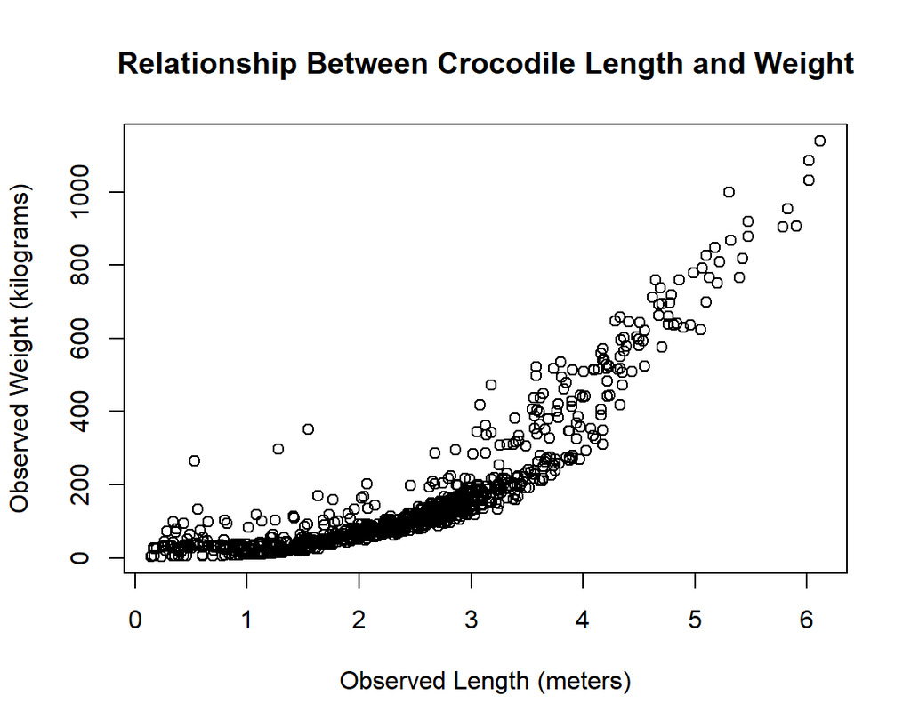

# Confidence and Prediction Intervals

**Confidence Interval:** We are 95% confident that for every 1 meter increase in length, the average crocodile weight increase by between 129.3 kilograms and 139.95 kilograms

[figure not shown]

# Evaluation

Concerns when applying a linear regression model:  
- Typical weight to length in animals is usually not exactly linear but following a more nonlinear trend  
- Any outliers or extremities could be ignored through a linear regression model  
- If the data set is small, the model may not be representative of all data values